# Sushi Simulation

Lance Dugger

## Problem Description

A restaurant is interested in predicting how much fresh tuna will be available on a daily basis. The following parameters will be used to build the model.

- Daily catch is dependent on on fishing conditions. Conditions occur as follows: Great: 10%, OK: 60%, Bad: 30%.
- Given the fishing conditions, the number of daily fish caught will be Poission distributed. The averages will be: Great: 7, OK: 4, Bad: 2
- The mix of Yellowfin to Bluefin tuna will be: 25% of occasions 0% Yellowfin; 50% of occasions 25% Yellowfin, 25% of occasions 35% Yellowfin.
- Fish weight is normally distributed with a standard deviation of 18 lbs. Average weight for Bluefin is 35 lbs and average weight for Yellowfin is 30lbs. Only fish weighing in excess of 20lbs are allowed to be kept based on Fish and Game regulations.
- Once fish are caught, the edible yield from each fish is determined by a Beta Distribution with $\alpha = 70$ and $\beta = 30$. For OK fishing conditions the percentage yield is unchanged. For Great fishing conditions the percentage yields is increased by 10%. For Bad fishing conditions the percentage yield is decreased by 25%.

Monte Carlo Simulation will be used to determine the expected amount of daily fresh tuna.

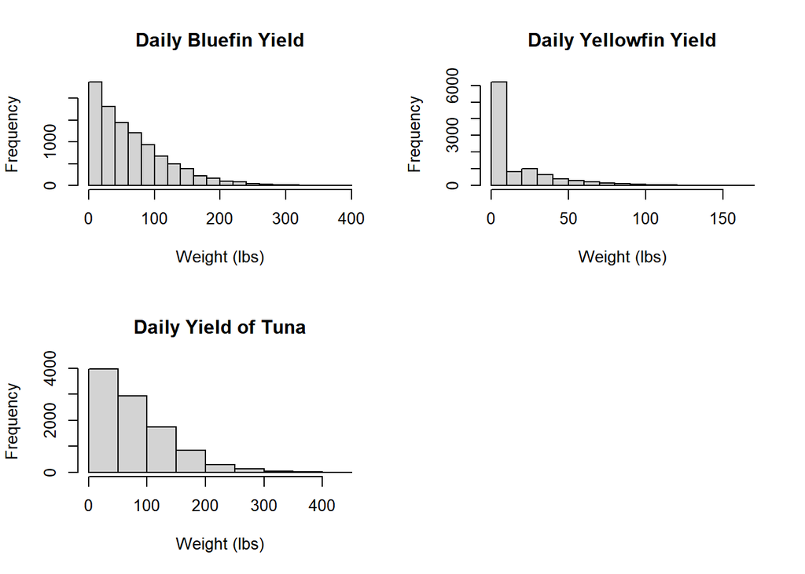

```r
#Initialize distribution for conditions
cond <- c("Great", "OK", "Bad")
cond_probs <- c(.1, .6, .3)

#Initialize distribution for fish ratio
scenario <- c(1, 2, 3)
scen_probs <- c(.25, .5, .25)

#Initialize fish ratios
species <- c("B", "Y")
scen1 <- c(1, 0)
scen2 <- c(.75, .25)
scen3 <- c(.65, .35)

#Initialize final data vectors
total_weight <- c()
total_B_weight <- c()
total_Y_weight <- c()

#Initialize number of repetitions
n <- 10000

for (i in 1:n){
  #Choose fishing conditions and ratio of yellowfin/bluefin
  weather <- sample(cond, 1, prob = cond_probs)
  ratio <- sample(scenario, 1, prob = scen_probs)

  #Initialize empty vectors for fish weights
  daily_B_weight <- c()
  daily_Y_weight <- c()
  daily_weight <- c()

  if (weather == "Great"){
    #Determine amount of fish caught
    fish <- rpois(1, 7)
    #Ensure that a zero length vector is not used.  It causes problems when multiplied by rnorm function.
    if (fish > 0){
      #Fill daily vector with combination of B's and Y's representing fish
      if (ratio == 1){
        daily <- sample(species, fish, prob = scen1, replace = TRUE)
      } else if (ratio == 2){
        daily <- sample(species, fish, prob = scen2, replace = TRUE)
      } else if (ratio == 3){
        daily <- sample(species, fish, prob = scen3, replace = TRUE)
      }
      for (j in 1:fish){
        #Determine weight of each fish based on B or Y designation
        if (daily[j] == "B"){
          weight <- rnorm(1, 35, 18)
          #Comply with fish and game regulations.  Also elimininates negative weights.
          if (weight <= 20){
            weight <- 0
          }
          #Determine yield from each fish
          weight <- weight * (rbeta(1, 70, 30) + 0.1)
          #Fill daily weight vectors with yield of each fish
          daily_weight[j] <- weight
          daily_B_weight[j] <- weight
          daily_Y_weight[j] <- 0
        } else if (daily[j] == "Y"){
          weight <- rnorm(1, 30, 18)
          if (weight <= 20){
            weight <- 0
          }
          weight <- weight * (rbeta(1, 70, 30) + 0.1)
          daily_weight[j] <- weight
          daily_B_weight[j] <- 0
          daily_Y_weight[j] <- weight
        }
      }
    } else {
      #If zero fish are produced, fill all three daily vectors with zeros
      daily_weight <- 0
      daily_B_weight <- 0
      daily_Y_weight <- 0
    }
    #Sum each daily vector into a total weight vector.  These are the final data vectors and represent total weight per day.
    total_weight[i] <- sum(daily_weight)
    total_B_weight[i] <- sum(daily_B_weight)
    total_Y_weight[i] <- sum(daily_Y_weight)

  } else if (weather == "OK"){
    fish <- rpois(1, 4)
    if (fish > 0){
      if (ratio == 1){
        daily <- sample(species, fish, prob = scen1, replace = TRUE)
      } else if (ratio == 2){
        daily <- sample(species, fish, prob = scen2, replace = TRUE)
      } else if (ratio == 3){
        daily <- sample(species, fish, prob = scen3, replace = TRUE)
      }
      for (j in 1:fish){
        if (daily[j] == "B"){
          weight <- rnorm(1, 35, 18)
          if (weight <= 20){
            weight <- 0
          }
          weight <- weight * rbeta(1, 70, 30)
          daily_weight[j] <- weight
          daily_B_weight[j] <- weight
          daily_Y_weight[j] <- 0
        } else if (daily[j] == "Y"){
          weight <- rnorm(1, 30, 18)
          if (weight <= 20){
            weight <- 0
          }
          weight <- weight * rbeta(1, 70, 30)
          daily_weight[j] <- weight
          daily_B_weight[j] <- 0
          daily_Y_weight[j] <- weight
        }
      }
    } else {
      daily_weight <- 0
      daily_B_weight <- 0
      daily_Y_weight <- 0
    }
    total_weight[i] <- sum(daily_weight)
    total_B_weight[i] <- sum(daily_B_weight)
    total_Y_weight[i] <- sum(daily_Y_weight)

  }else if (weather == "Bad"){
    fish <- rpois(1, 2)
    if (fish > 0){
      if (ratio == 1){
        daily <- sample(species, fish, prob = scen1, replace = TRUE)
      } else if (ratio == 2){
        daily <- sample(species, fish, prob = scen2, replace = TRUE)
      } else if (ratio == 3){
        daily <- sample(species, fish, prob = scen3, replace = TRUE)
      }
      for (j in 1:fish){
        if (daily[j] == "B"){
          weight <- rnorm(1, 35, 18)
          if (weight <= 20){
            weight <- 0
          }
          weight <- weight * (rbeta(1, 70, 30) - .25)
          daily_weight[j] <- weight
          daily_B_weight[j] <- weight
          daily_Y_weight[j] <- 0
        } else if (daily[j] == "Y"){
          weight <- rnorm(1, 30, 18)
          if (weight <= 20){
            weight <- 0
          }
          weight <- weight * (rbeta(1, 70, 30) - .25)
          daily_weight[j] <- weight
          daily_B_weight[j] <- 0
          daily_Y_weight[j] <- weight
        }
      }
    } else {
      daily_weight <- 0
      daily_B_weight <- 0
      daily_Y_weight <- 0
    }
    total_weight[i] <- sum(daily_weight)
    total_B_weight[i] <- sum(daily_B_weight)
    total_Y_weight[i] <- sum(daily_Y_weight)
  }
}

#Final Statistics
B_avg = round(mean(total_B_weight))
Y_avg = round(mean(total_Y_weight))
tot_avg = round(mean(total_weight))
B_med = round(median(total_B_weight))
Y_med = round(median(total_Y_weight))
tot_med = round(median(total_weight))
nofish = sum(total_weight ==0)

#Create table of fish statistics to print in console
fish_facts <- matrix(c(B_avg, Y_avg, tot_avg, paste(nofish/n*100, "%",""), B_med, Y_med, tot_med, paste(nofish, "days","")), ncol = 2)
rownames(fish_facts) <- c("Bluefin Daily Stats (lbs)", "Yellowfin Daily Stats (lbs)", "Total Daily Stats (lbs) ", "No Fish Days")
colnames(fish_facts) <- c("Average", "Median")
fish_facts <- as.table(fish_facts)

#Graph
par(mfrow = c(2, 2))
hist(total_B_weight, main = 'Daily Bluefin Yield', xlab = "Weight (lbs)")
hist(total_Y_weight, main = 'Daily Yellowfin Yield', xlab = "Weight (lbs)")
hist(total_weight, main = 'Daily Yield of Tuna', xlab = "Weight (lbs)")
par(mfrow = c(1, 1))
```

```r
fish_facts
```

```
##                             Average Median
## Bluefin Daily Stats (lbs)   65      51
## Yellowfin Daily Stats (lbs) 15      0
## Total Daily Stats (lbs)     79      66
## No Fish Days                9.16 %  916 days
```